[figure not shown]

[figure not shown]

# What is Pandas?

Pandas is a Python library used for working with data sets.

It has functions for analyzing, cleaning, exploring, and manipulating data.

The name "Pandas" has a reference to both "Panel Data", and "Python Data Analysis" and was created by Wes McKinney in 2008.

# Why Use Pandas?

Pandas allows us to analyze big data and make conclusions based on statistical theories.

Pandas can clean messy data sets, and make them readable and relevant.

Relevant data is very important in data science.

**Data Science**: is a branch of computer science where we study how to store, use and analyze data for deriving information from it.

# What Can Pandas Do?

Pandas gives you answers about the data. Like:

Is there a correlation between two or more columns? What is average value? Max value? Min value? Pandas are also able to delete rows that are not relevant, or contains wrong values, like empty or NULL values. This is called cleaning the data.

# Installation of Pandas

If you have Python and PIP already installed on a system, then installation of Pandas is very easy.

Install it using this command:

```python
!pip install pandas
```

## Import Pandas

Once Pandas is installed, import it in your applications by adding the import keyword:

```python
import pandas
```

```python
import pandas

mydataset = {
  'cars': ["BMW", "Volvo", "Ford"],
  'passings': [3, 7, 2]
}

myvar = pandas.DataFrame(mydataset)

print(myvar)
```

```
    cars  passings
0    BMW         3
1  Volvo         7
2   Ford         2
```

# Pandas as pd

Pandas is usually imported under the pd alias.

**alias**: In Python alias are an alternate name for referring to the same thing.

Create an alias with the as keyword while importing:

```python
import pandas as pd
```

Now the Pandas package can be referred to as pd instead of pandas.

```python
import pandas as pd

mydataset = {
  'cars': ["BMW", "Volvo", "Ford"],
  'passings': [3, 7, 2]
}

myvar = pd.DataFrame(mydataset)

print(myvar)
```

```
    cars  passings
0    BMW         3
1  Volvo         7
2   Ford         2
```

## Checking Pandas Version

The version string is stored under **version** attribute.

```python
import pandas as pd

print(pd.__version__)
```

```
1.0.1
```

# Pandas Series

## What is a Series?

A Pandas Series is like a column in a table.

It is a one-dimensional array holding data of any type.

```python
#Create a simple Pandas Series from a list
import pandas as pd

a = [1, 7, 2]

myvar = pd.Series(a)

print(myvar)
```

```
0    1
1    7
2    2
dtype: int64
```

```python
#Create a simple Pandas Series from a list
import pandas as pd
Name = ["Avery Bradley","John Holland", "Jonas Jerebko","Jordan Mickey","Terry Rozier",
        "Jared Sullinger","Evan Turner"]
ser = pd.Series(Name)
print(ser)
```

```
0      Avery Bradley
1       John Holland
2      Jonas Jerebko
3      Jordan Mickey
4       Terry Rozier
5    Jared Sullinger
6        Evan Turner
dtype: object
```

## Labels

If nothing else is specified, the values are labeled with their index number. First value has index 0, second value has index 1 etc.

This label can be used to access a specified value.

### usind labels

```python
import pandas as pd

a = [1, 7, 2]

myvar = pd.Series(a, index = ["x", "y", "z"])

print(myvar)
```

```
x    1
y    7
z    2
dtype: int64
```

```python
# Return the value of "y":
print(myvar["y"])
```

```
7
```

```python
# import pandas and numpy
import pandas as pd
import numpy as np

# creating simple array
data = np.array(['g','e','e','k','s','f', 'o','r','g','e','e','k','s'])
ser = pd.Series(data,index=["10","11","12","13","14","15","16","17","18","19","20","21","22"])

# accessing a element using label "index"
print(ser["16"])
print(ser[["16","15"]])
```

```
o
16    o
15    f
dtype: object
```

### using index

```python
# import pandas and numpy
import pandas as pd
import numpy as np

# creating simple array
data = np.array(['g','e','e','k','s','f', 'o','r','g','e','e','k','s'])
ser = pd.Series(data)
#retrieve the first 5 elements
print("\n",ser[:5])
print("\n",ser[[0,1,2,4]])
#retrieve element
print("\n- 5th ele. is ",ser[5])
```

```
 0    g
1    e
2    e
3    k
4    s
dtype: object

 0    g
1    e
2    e
4    s
dtype: object

- 5th ele. is  f
```

## Key/Value Objects as Series

You can also use a key/value object, like a dictionary, when creating a Series.

```python
# Create a simple Pandas Series from a dictionary:

import pandas as pd

calories = {"day1": [420,50], "day2": [380,34], "day3": [390,43]}

myvar = pd.Series(calories)

print(myvar)
print("\nDay1 data =",myvar["day1"])
```

```
day1    [420, 50]
day2    [380, 34]
day3    [390, 43]
dtype: object

Day1 data = [420, 50]
```

```python
print(myvar[0])
```

```
[420, 50]
```

**Note: The keys of the dictionary become the labels.**

To select only some of the items in the dictionary, use the index argument and specify only the items you want to include in the Series.

Create a Series using only data from "day1" and "day2":

```python
import pandas as pd

calories = {"day1": 420, "day2": 380, "day3": 390}

myvar = pd.Series(calories, index = ["day1", "day2"])

print(myvar)
```

```
day1    420
day2    380
dtype: int64
```

# DataFrames

Data sets in Pandas are usually multi-dimensional tables, called DataFrames.

Series is like a column, a DataFrame is the whole table.

```python
#Create a DataFrame from two Series:
import pandas as pd

data = {
  "calories": [420, 380, 390],
  "duration": [50, 40, 45]
}

myvar = pd.DataFrame(data)

print(myvar)
```

```
   calories  duration
0       420        50
1       380        40
2       390        45
```

# Pandas DataFrames

#### #1

```python
# Import pandas library
import pandas as pd

# initialize list of lists
data = [['tom', 10], ['nick', 15], ['juli', 14]]
# Create the pandas DataFrame
df = pd.DataFrame(data, columns = ['Name', 'Age'])
# print dataframe.
df
```

|  | Name | Age |
| --- | --- | --- |
| 0 | tom | 10 |
| 1 | nick | 15 |
| 2 | juli | 14 |

### #2

```python
# Python code demonstrate creating
# DataFrame from dict narray / lists
# By default addresses.

import pandas as pd

# initialise data of lists.
data = {'Name':['Tom', 'nick', 'krish', 'jack'],
     'Age':[20, 21, 19, 18]}
# Create DataFrame
df = pd.DataFrame(data)
# Print the output.
df
```

|  | Name | Age |
| --- | --- | --- |
| 0 | Tom | 20 |
| 1 | nick | 21 |
| 2 | krish | 19 |
| 3 | jack | 18 |

### #3

```python
# Python code demonstrate creating
# pandas DataFrame with indexed by

# DataFrame using arrays.
import pandas as pd
# initialise data of lists.
data = {'Name':['Tom', 'Jack', 'nick', 'juli'],'marks':[99, 98, 95, 90]}
# Creates pandas DataFrame.
df = pd.DataFrame(data, index =['rank1',
'rank2','rank3','rank4'])
# print the data
df
```

|  | Name | marks |
| --- | --- | --- |
| rank1 | Tom | 99 |
| rank2 | Jack | 98 |
| rank3 | nick | 95 |
| rank4 | juli | 90 |

### #4

```python
# Python code demonstrate how to create
# Pandas DataFrame by lists of dicts.
import pandas as pd
# Initialise data to lists.
data = [{'a': 1, 'b': 2, 'c':3},
{'a':10, 'b': 20, 'c': 30}]
# Creates DataFrame.
df = pd.DataFrame(data)
# Print the data
df
```

|  | a | b | c |
| --- | --- | --- | --- |
| 0 | 1 | 2 | 3 |
| 1 | 10 | 20 | 30 |

### #5

```python
# Python program to demonstrate creating
# pandas Datadaframe from lists using zip.

import pandas as pd
# List1
Name = ['tom', 'krish', 'nick', 'juli']
# List2
Age = [25, 30, 26, 22]
# get the list of tuples from two lists.
# and merge them by using zip().
print(list(zip(Name, Age)))
list_of_tuples = list(zip(Name, Age))
# Assign data to tuples.
list_of_tuples
# Converting lists of tuples into
# pandas Dataframe.
df = pd.DataFrame(list_of_tuples,
columns = ['Name', 'Age'])
# Print data.
df
```

```
[('tom', 25), ('krish', 30), ('nick', 26), ('juli', 22)]
```

|  | Name | Age |
| --- | --- | --- |
| 0 | tom | 25 |
| 1 | krish | 30 |
| 2 | nick | 26 |
| 3 | juli | 22 |

### #6

```python
# Python code demonstrate creating
# Pandas Dataframe from Dicts of series.

import pandas as pd

# Initialise data to Dicts of series.
d = {'one' : pd.Series([10, 20, 30, 40],
index =['a', 'b', 'c', 'd']),'two' : pd.Series([10, 20, 30, 40],index =['a', 'b', 'c', 'd'])}

# creates Dataframe.
df = pd.DataFrame(d)

# print the data.
df
```

|  | one | two |
| --- | --- | --- |
| a | 10 | 10 |
| b | 20 | 20 |
| c | 30 | 30 |
| d | 40 | 40 |

```python
# Python code demonstrate creating
# Pandas Dataframe from Dicts of series.

import pandas as pd

# Initialise data to Dicts of series.
d = {'one' :[10, 20, 30, 40]
,'two' :[10, 20, 30, 40]}

# creates Dataframe.
df = pd.DataFrame(d, index=["a","b","c","d"])

# print the data.
df
```

|  | one | two |
| --- | --- | --- |
| a | 10 | 10 |
| b | 20 | 20 |
| c | 30 | 30 |
| d | 40 | 40 |

## What is a DataFrame?

A Pandas DataFrame is a 2 dimensional data structure, like a 2 dimensional array, or a table with rows and columns.

```python
import pandas as pd

data = {
  "calories": [420, 380, 390],
  "duration": [50, 40, 45]
}

#load data into a DataFrame object:
df = pd.DataFrame(data)

print(df)
```

```
   calories  duration
0       420        50
1       380        40
2       390        45
```

## Locate Row

As you can see from the result above, the DataFrame is like a table with rows and columns.

Pandas use the loc attribute to return one or more specified row(s)

```python
#refer to the row index:
print(df.loc[0:1,"calories"])
```

```
0    420
1    380
Name: calories, dtype: int64
```

Return row 0 and 1:

```python
#use a list of indexes:
print(df.loc[[0,1]])
```

```
   calories  duration
0       420        50
1       380        40
```

## Named Indexes

With the index argument, you can name your own indexes.

```python
#Add a list of names to give each row a name:


import pandas as pd

data = {
  "calories": [420, 380, 390],
  "duration": [50, 40, 45]
}

df = pd.DataFrame(data, index = ["day1", "day2", "day3"])

print(df)
```

```
      calories  duration
day1       420        50
day2       380        40
day3       390        45
```

## Locate Named Indexes

Use the named index in the loc attribute to return the specified row(s).

```python
#refer to the named index:
print(df.loc[["day2","day3"],"calories"])
```

```
day2    380
day3    390
Name: calories, dtype: int64
```

## Load Files Into a DataFrame

If your data sets are stored in a file, Pandas can load them into a DataFrame.

# Read and write CSV Files

A simple way to store big data sets is to use CSV files (comma separated files).

CSV files contains plain text and is a well know format that can be read by everyone including Pandas.

In our examples we will be using a CSV file called 'data.csv'.

```python
#Load the CSV into a DataFrame:
import pandas as pd
df = pd.read_csv('dataset/data.csv')
print(df)
```

```
     Duration  Pulse  Maxpulse  Calories
0          60    110       130     409.1
1          60    117       145     479.0
2          60    103       135     340.0
3          45    109       175     282.4
4          45    117       148     406.0
..        ...    ...       ...       ...
164        60    105       140     290.8
165        60    110       145     300.0
166        60    115       145     310.2
167        75    120       150     320.4
168        75    125       150     330.4

[169 rows x 4 columns]
```

```python
df.head()
```

|  | Duration | Pulse | Maxpulse | Calories |
| --- | --- | --- | --- | --- |
| 0 | 60 | 110 | 130 | 409.1 |
| 1 | 60 | 117 | 145 | 479.0 |
| 2 | 60 | 103 | 135 | 340.0 |
| 3 | 45 | 109 | 175 | 282.4 |
| 4 | 45 | 117 | 148 | 406.0 |

```python
df.head(10)
```

|  | Duration | Pulse | Maxpulse | Calories |
| --- | --- | --- | --- | --- |
| 0 | 60 | 110 | 130 | 409.1 |
| 1 | 60 | 117 | 145 | 479.0 |
| 2 | 60 | 103 | 135 | 340.0 |
| 3 | 45 | 109 | 175 | 282.4 |
| 4 | 45 | 117 | 148 | 406.0 |
| 5 | 60 | 102 | 127 | 300.0 |
| 6 | 60 | 110 | 136 | 374.0 |
| 7 | 45 | 104 | 134 | 253.3 |
| 8 | 30 | 109 | 133 | 195.1 |
| 9 | 60 | 98 | 124 | 269.0 |

```python
df.tail(10)
```

|  | Duration | Pulse | Maxpulse | Calories |
| --- | --- | --- | --- | --- |
| 159 | 30 | 80 | 120 | 240.9 |
| 160 | 30 | 85 | 120 | 250.4 |
| 161 | 45 | 90 | 130 | 260.4 |
| 162 | 45 | 95 | 130 | 270.0 |
| 163 | 45 | 100 | 140 | 280.9 |
| 164 | 60 | 105 | 140 | 290.8 |
| 165 | 60 | 110 | 145 | 300.0 |
| 166 | 60 | 115 | 145 | 310.2 |
| 167 | 75 | 120 | 150 | 320.4 |
| 168 | 75 | 125 | 150 | 330.4 |

**Tip: use to_string() to print the** **entire DataFrame.**

# data encoding problem

```python
# modules we'll use
import pandas as pd
import numpy as np
# helpful character encoding module
import chardet
```

```python
police_killings =pd.read_csv("PoliceKillingsUS.csv")
```

[output not shown]

[output cut: 8 more lines]

[output not shown]

```python
with open("PoliceKillingsUS.csv", 'rb') as rawdata:
         result = chardet.detect(rawdata.read())

         DATA=rawdata.read()
# check what the character encoding might be
print(result)
```

```
{'encoding': 'Windows-1252', 'confidence': 0.73, 'language': ''}
```

```python
police_killings =pd.read_csv("PoliceKillingsUS.csv",encoding='Windows-1252')
police_killings
```

|  | id | name | date | manner_of_death | armed | age | gender | race | city | state | signs_of_mental_illness | threat_level | flee | body_camera |
| --- | --- | --- | --- | --- | --- | --- | --- | --- | --- | --- | --- | --- | --- | --- |
| 0 | 3 | Tim Elliot | 02/01/15 | shot | gun | 53.0 | M | A | Shelton | WA | True | attack | Not fleeing | False |
| 1 | 4 | Lewis Lee Lembke | 02/01/15 | shot | gun | 47.0 | M | W | Aloha | OR | False | attack | Not fleeing | False |
| 2 | 5 | John Paul Quintero | 03/01/15 | shot and Tasered | unarmed | 23.0 | M | H | Wichita | KS | False | other | Not fleeing | False |
| 3 | 8 | Matthew Hoffman | 04/01/15 | shot | toy weapon | 32.0 | M | W | San Francisco | CA | True | attack | Not fleeing | False |
| 4 | 9 | Michael Rodriguez | 04/01/15 | shot | nail gun | 39.0 | M | H | Evans | CO | False | attack | Not fleeing | False |
| ... | ... | ... | ... | ... | ... | ... | ... | ... | ... | ... | ... | ... | ... | ... |
| 2530 | 2822 | Rodney E. Jacobs | 28/07/17 | shot | gun | 31.0 | M | NaN | Kansas City | MO | False | attack | Not fleeing | False |
| 2531 | 2813 | TK TK | 28/07/17 | shot | vehicle | NaN | M | NaN | Albuquerque | NM | False | attack | Car | False |
| 2532 | 2818 | Dennis W. Robinson | 29/07/17 | shot | gun | 48.0 | M | NaN | Melba | ID | False | attack | Car | False |
| 2533 | 2817 | Isaiah Tucker | 31/07/17 | shot | vehicle | 28.0 | M | B | Oshkosh | WI | False | attack | Car | True |
| 2534 | 2815 | Dwayne Jeune | 31/07/17 | shot | knife | 32.0 | M | B | Brooklyn | NY | True | attack | Not fleeing | False |

2535 rows × 14 columns

```python
police_killings =pd.read_csv("PoliceKillingsUS.csv",index_col=0,encoding='Windows-1252')
police_killings
```

| id | name | date | manner_of_death | armed | age | gender | race | city | state | signs_of_mental_illness | threat_level | flee | body_camera |
| --- | --- | --- | --- | --- | --- | --- | --- | --- | --- | --- | --- | --- | --- |
| 3 | Tim Elliot | 02/01/15 | shot | gun | 53.0 | M | A | Shelton | WA | True | attack | Not fleeing | False |
| 4 | Lewis Lee Lembke | 02/01/15 | shot | gun | 47.0 | M | W | Aloha | OR | False | attack | Not fleeing | False |
| 5 | John Paul Quintero | 03/01/15 | shot and Tasered | unarmed | 23.0 | M | H | Wichita | KS | False | other | Not fleeing | False |
| 8 | Matthew Hoffman | 04/01/15 | shot | toy weapon | 32.0 | M | W | San Francisco | CA | True | attack | Not fleeing | False |
| 9 | Michael Rodriguez | 04/01/15 | shot | nail gun | 39.0 | M | H | Evans | CO | False | attack | Not fleeing | False |
| ... | ... | ... | ... | ... | ... | ... | ... | ... | ... | ... | ... | ... | ... |
| 2822 | Rodney E. Jacobs | 28/07/17 | shot | gun | 31.0 | M | NaN | Kansas City | MO | False | attack | Not fleeing | False |
| 2813 | TK TK | 28/07/17 | shot | vehicle | NaN | M | NaN | Albuquerque | NM | False | attack | Car | False |
| 2818 | Dennis W. Robinson | 29/07/17 | shot | gun | 48.0 | M | NaN | Melba | ID | False | attack | Car | False |
| 2817 | Isaiah Tucker | 31/07/17 | shot | vehicle | 28.0 | M | B | Oshkosh | WI | False | attack | Car | True |
| 2815 | Dwayne Jeune | 31/07/17 | shot | knife | 32.0 | M | B | Brooklyn | NY | True | attack | Not fleeing | False |

2535 rows × 13 columns

### save the csv file

```python
police_killings.to_csv("encoded_PK.csv")
```

## read the csv file

```python
data=pd.read_csv("encoded_PK.csv")
data
```

|  | id | name | date | manner_of_death | armed | age | gender | race | city | state | signs_of_mental_illness | threat_level | flee | body_camera |
| --- | --- | --- | --- | --- | --- | --- | --- | --- | --- | --- | --- | --- | --- | --- |
| 0 | 3 | Tim Elliot | 02/01/15 | shot | gun | 53.0 | M | A | Shelton | WA | True | attack | Not fleeing | False |
| 1 | 4 | Lewis Lee Lembke | 02/01/15 | shot | gun | 47.0 | M | W | Aloha | OR | False | attack | Not fleeing | False |
| 2 | 5 | John Paul Quintero | 03/01/15 | shot and Tasered | unarmed | 23.0 | M | H | Wichita | KS | False | other | Not fleeing | False |
| 3 | 8 | Matthew Hoffman | 04/01/15 | shot | toy weapon | 32.0 | M | W | San Francisco | CA | True | attack | Not fleeing | False |
| 4 | 9 | Michael Rodriguez | 04/01/15 | shot | nail gun | 39.0 | M | H | Evans | CO | False | attack | Not fleeing | False |
| ... | ... | ... | ... | ... | ... | ... | ... | ... | ... | ... | ... | ... | ... | ... |
| 2530 | 2822 | Rodney E. Jacobs | 28/07/17 | shot | gun | 31.0 | M | NaN | Kansas City | MO | False | attack | Not fleeing | False |
| 2531 | 2813 | TK TK | 28/07/17 | shot | vehicle | NaN | M | NaN | Albuquerque | NM | False | attack | Car | False |
| 2532 | 2818 | Dennis W. Robinson | 29/07/17 | shot | gun | 48.0 | M | NaN | Melba | ID | False | attack | Car | False |
| 2533 | 2817 | Isaiah Tucker | 31/07/17 | shot | vehicle | 28.0 | M | B | Oshkosh | WI | False | attack | Car | True |
| 2534 | 2815 | Dwayne Jeune | 31/07/17 | shot | knife | 32.0 | M | B | Brooklyn | NY | True | attack | Not fleeing | False |

2535 rows × 14 columns

### rename columns then save the dataframe to csv file

```python
data = {
    'CHN': {'COUNTRY': 'China', 'POP': 1_398.72, 'AREA': 9_596.96,
            'GDP': 12_234.78, 'CONT': 'Asia'},
    'IND': {'COUNTRY': 'India', 'POP': 1_351.16, 'AREA': 3_287.26,
            'GDP': 2_575.67, 'CONT': 'Asia', 'IND_DAY': '1947-08-15'},
    'USA': {'COUNTRY': 'US', 'POP': 329.74, 'AREA': 9_833.52,
            'GDP': 19_485.39, 'CONT': 'N.America',
            'IND_DAY': '1776-07-04'},
    'IDN': {'COUNTRY': 'Indonesia', 'POP': 268.07, 'AREA': 1_910.93,
            'GDP': 1_015.54, 'CONT': 'Asia', 'IND_DAY': '1945-08-17'},
    'BRA': {'COUNTRY': 'Brazil', 'POP': 210.32, 'AREA': 8_515.77,
            'GDP': 2_055.51, 'CONT': 'S.America', 'IND_DAY': '1822-09-07'},
    'PAK': {'COUNTRY': 'Pakistan', 'POP': 205.71, 'AREA': 881.91,
            'GDP': 302.14, 'CONT': 'Asia', 'IND_DAY': '1947-08-14'},
    'NGA': {'COUNTRY': 'Nigeria', 'POP': 200.96, 'AREA': 923.77,
            'GDP': 375.77, 'CONT': 'Africa', 'IND_DAY': '1960-10-01'},
    'BGD': {'COUNTRY': 'Bangladesh', 'POP': 167.09, 'AREA': 147.57,
            'GDP': 245.63, 'CONT': 'Asia', 'IND_DAY': '1971-03-26'},
    'RUS': {'COUNTRY': 'Russia', 'POP': 146.79, 'AREA': 17_098.25,
            'GDP': 1_530.75, 'IND_DAY': '1992-06-12'},
    'MEX': {'COUNTRY': 'Mexico', 'POP': 126.58, 'AREA': 1_964.38,
            'GDP': 1_158.23, 'CONT': 'N.America', 'IND_DAY': '1810-09-16'},
    'JPN': {'COUNTRY': 'Japan', 'POP': 126.22, 'AREA': 377.97,
            'GDP': 4_872.42, 'CONT': 'Asia'},
    'DEU': {'COUNTRY': 'Germany', 'POP': 83.02, 'AREA': 357.11,
            'GDP': 3_693.20, 'CONT': 'Europe'},
    'FRA': {'COUNTRY': 'France', 'POP': 67.02, 'AREA': 640.68,
            'GDP': 2_582.49, 'CONT': 'Europe', 'IND_DAY': '1789-07-14'},
    'GBR': {'COUNTRY': 'UK', 'POP': 66.44, 'AREA': 242.50,
            'GDP': 2_631.23, 'CONT': 'Europe'},
    'ITA': {'COUNTRY': 'Italy', 'POP': 60.36, 'AREA': 301.34,
            'GDP': 1_943.84, 'CONT': 'Europe'},
    'ARG': {'COUNTRY': 'Argentina', 'POP': 44.94, 'AREA': 2_780.40,
            'GDP': 637.49, 'CONT': 'S.America', 'IND_DAY': '1816-07-09'},
    'DZA': {'COUNTRY': 'Algeria', 'POP': 43.38, 'AREA': 2_381.74,
            'GDP': 167.56, 'CONT': 'Africa', 'IND_DAY': '1962-07-05'},
    'CAN': {'COUNTRY': 'Canada', 'POP': 37.59, 'AREA': 9_984.67,
            'GDP': 1_647.12, 'CONT': 'N.America', 'IND_DAY': '1867-07-01'},
    'AUS': {'COUNTRY': 'Australia', 'POP': 25.47, 'AREA': 7_692.02,
            'GDP': 1_408.68, 'CONT': 'Oceania'},
    'KAZ': {'COUNTRY': 'Kazakhstan', 'POP': 18.53, 'AREA': 2_724.90,
            'GDP': 159.41, 'CONT': 'Asia', 'IND_DAY': '1991-12-16'}
}

columns = ('COUNTRY', 'POP', 'AREA', 'GDP', 'CONT', 'IND_DAY')
```

```python
df = pd.DataFrame(data=data).T
```

```python
df.head()
```

|  | COUNTRY | POP | AREA | GDP | CONT | IND_DAY |
| --- | --- | --- | --- | --- | --- | --- |
| CHN | China | 1398.72 | 9596.96 | 12234.8 | Asia | NaN |
| IND | India | 1351.16 | 3287.26 | 2575.67 | Asia | 1947-08-15 |
| USA | US | 329.74 | 9833.52 | 19485.4 | N.America | 1776-07-04 |
| IDN | Indonesia | 268.07 | 1910.93 | 1015.54 | Asia | 1945-08-17 |
| BRA | Brazil | 210.32 | 8515.77 | 2055.51 | S.America | 1822-09-07 |

### rename columns

```python
df.rename(columns={'POP': 'score',"IND_DAY":"day"},inplace=True)
df.head()
```

|  | COUNTRY | score | AREA | GDP | CONT | day |
| --- | --- | --- | --- | --- | --- | --- |
| CHN | China | 1398.72 | 9596.96 | 12234.8 | Asia | NaN |
| IND | India | 1351.16 | 3287.26 | 2575.67 | Asia | 1947-08-15 |
| USA | US | 329.74 | 9833.52 | 19485.4 | N.America | 1776-07-04 |
| IDN | Indonesia | 268.07 | 1910.93 | 1015.54 | Asia | 1945-08-17 |
| BRA | Brazil | 210.32 | 8515.77 | 2055.51 | S.America | 1822-09-07 |

### save it to csv file

```python
df.to_csv('dataset/dataset.csv')
```

```python
df = pd.read_csv('dataset/dataset.csv', index_col=0)
df.head()
```

|  | COUNTRY | score | AREA | GDP | CONT | day |
| --- | --- | --- | --- | --- | --- | --- |
| CHN | China | 1398.72 | 9596.96 | 12234.78 | Asia | NaN |
| IND | India | 1351.16 | 3287.26 | 2575.67 | Asia | 1947-08-15 |
| USA | US | 329.74 | 9833.52 | 19485.39 | N.America | 1776-07-04 |
| IDN | Indonesia | 268.07 | 1910.93 | 1015.54 | Asia | 1945-08-17 |
| BRA | Brazil | 210.32 | 8515.77 | 2055.51 | S.America | 1822-09-07 |

# Handling Missing Values

```python
df.head()
```

|  | COUNTRY | score | AREA | GDP | CONT | day |
| --- | --- | --- | --- | --- | --- | --- |
| CHN | China | 1398.72 | 9596.96 | 12234.78 | Asia | NaN |
| IND | India | 1351.16 | 3287.26 | 2575.67 | Asia | 1947-08-15 |
| USA | US | 329.74 | 9833.52 | 19485.39 | N.America | 1776-07-04 |
| IDN | Indonesia | 268.07 | 1910.93 | 1015.54 | Asia | 1945-08-17 |
| BRA | Brazil | 210.32 | 8515.77 | 2055.51 | S.America | 1822-09-07 |

```python
data=pd.read_csv("football-players-data.csv", index_col=0)
```

```python
data.head()
```

|  | ID | Name | Age | Photo | Nationality | Flag | Overall | Potential | Club | Club Logo | ... | Composure | Marking | StandingTackle | SlidingTackle | GKDiving | GKHandling | GKKicking | GKPositioning | GKReflexes | Release Clause |
| --- | --- | --- | --- | --- | --- | --- | --- | --- | --- | --- | --- | --- | --- | --- | --- | --- | --- | --- | --- | --- | --- |
| 0 | 158023 | L. Messi | 31 | https://cdn.sofifa.org/players/4/19/158023.png | Argentina | https://cdn.sofifa.org/flags/52.png | 94 | 94 | FC Barcelona | https://cdn.sofifa.org/teams/2/light/241.png | ... | 96.0 | 33.0 | 28.0 | 26.0 | 6.0 | 11.0 | 15.0 | 14.0 | 8.0 | €226.5M |
| 1 | 20801 | Cristiano Ronaldo | 33 | https://cdn.sofifa.org/players/4/19/20801.png | Portugal | https://cdn.sofifa.org/flags/38.png | 94 | 94 | Juventus | https://cdn.sofifa.org/teams/2/light/45.png | ... | 95.0 | 28.0 | 31.0 | 23.0 | 7.0 | 11.0 | 15.0 | 14.0 | 11.0 | €127.1M |
| 2 | 190871 | Neymar Jr | 26 | https://cdn.sofifa.org/players/4/19/190871.png | Brazil | https://cdn.sofifa.org/flags/54.png | 92 | 93 | Paris Saint-Germain | https://cdn.sofifa.org/teams/2/light/73.png | ... | 94.0 | 27.0 | 24.0 | 33.0 | 9.0 | 9.0 | 15.0 | 15.0 | 11.0 | €228.1M |
| 3 | 193080 | De Gea | 27 | https://cdn.sofifa.org/players/4/19/193080.png | Spain | https://cdn.sofifa.org/flags/45.png | 91 | 93 | Manchester United | https://cdn.sofifa.org/teams/2/light/11.png | ... | 68.0 | 15.0 | 21.0 | 13.0 | 90.0 | 85.0 | 87.0 | 88.0 | 94.0 | €138.6M |
| 4 | 192985 | K. De Bruyne | 27 | https://cdn.sofifa.org/players/4/19/192985.png | Belgium | https://cdn.sofifa.org/flags/7.png | 91 | 92 | Manchester City | https://cdn.sofifa.org/teams/2/light/10.png | ... | 88.0 | 68.0 | 58.0 | 51.0 | 15.0 | 13.0 | 5.0 | 10.0 | 13.0 | €196.4M |

5 rows × 88 columns

## How many missing data points do we have?

Ok, now we know that we do have some missing values. Let's see how many we have in each column.

```python
print(data.to_string())
```

[output not shown]

```python
data.info()
```

```
<class 'pandas.core.frame.DataFrame'>
Int64Index: 18207 entries, 0 to 18206
Data columns (total 88 columns):
 #   Column                    Non-Null Count  Dtype
---  ------                    --------------  -----
 0   ID                        18207 non-null  int64
 1   Name                      18207 non-null  object
 2   Age                       18207 non-null  int64
 3   Photo                     18207 non-null  object
 4   Nationality               18207 non-null  object
 5   Flag                      18207 non-null  object
 6   Overall                   18207 non-null  int64
 7   Potential                 18207 non-null  int64
 8   Club                      17966 non-null  object
 9   Club Logo                 18207 non-null  object
```

[output cut: 80 more lines]

```python
missing_Data_count_per_column=data.isnull().sum()
```

```python
missing_Data_count_per_column
```

```
ID                   0
Name                 0
Age                  0
Photo                0
Nationality          0
                  ...
GKHandling          48
GKKicking           48
GKPositioning       48
GKReflexes          48
Release Clause    1564
Length: 88, dtype: int64
```

```python
missing_Data_count_per_column.sum()
```

```
76984
```

```python
data.isna()
```

|  | ID | Name | Age | Photo | Nationality | Flag | Overall | Potential | Club | Club Logo | ... | Composure | Marking | StandingTackle | SlidingTackle | GKDiving | GKHandling | GKKicking | GKPositioning | GKReflexes | Release Clause |
| --- | --- | --- | --- | --- | --- | --- | --- | --- | --- | --- | --- | --- | --- | --- | --- | --- | --- | --- | --- | --- | --- |
| 0 | False | False | False | False | False | False | False | False | False | False | ... | False | False | False | False | False | False | False | False | False | False |
| 1 | False | False | False | False | False | False | False | False | False | False | ... | False | False | False | False | False | False | False | False | False | False |
| 2 | False | False | False | False | False | False | False | False | False | False | ... | False | False | False | False | False | False | False | False | False | False |
| 3 | False | False | False | False | False | False | False | False | False | False | ... | False | False | False | False | False | False | False | False | False | False |
| 4 | False | False | False | False | False | False | False | False | False | False | ... | False | False | False | False | False | False | False | False | False | False |
| ... | ... | ... | ... | ... | ... | ... | ... | ... | ... | ... | ... | ... | ... | ... | ... | ... | ... | ... | ... | ... | ... |
| 18202 | False | False | False | False | False | False | False | False | False | False | ... | False | False | False | False | False | False | False | False | False | False |
| 18203 | False | False | False | False | False | False | False | False | False | False | ... | False | False | False | False | False | False | False | False | False | False |
| 18204 | False | False | False | False | False | False | False | False | False | False | ... | False | False | False | False | False | False | False | False | False | False |
| 18205 | False | False | False | False | False | False | False | False | False | False | ... | False | False | False | False | False | False | False | False | False | False |
| 18206 | False | False | False | False | False | False | False | False | False | False | ... | False | False | False | False | False | False | False | False | False | False |

18207 rows × 88 columns

```python
data.isnull()
```

|  | ID | Name | Age | Photo | Nationality | Flag | Overall | Potential | Club | Club Logo | ... | Composure | Marking | StandingTackle | SlidingTackle | GKDiving | GKHandling | GKKicking | GKPositioning | GKReflexes | Release Clause |
| --- | --- | --- | --- | --- | --- | --- | --- | --- | --- | --- | --- | --- | --- | --- | --- | --- | --- | --- | --- | --- | --- |
| 0 | False | False | False | False | False | False | False | False | False | False | ... | False | False | False | False | False | False | False | False | False | False |
| 1 | False | False | False | False | False | False | False | False | False | False | ... | False | False | False | False | False | False | False | False | False | False |
| 2 | False | False | False | False | False | False | False | False | False | False | ... | False | False | False | False | False | False | False | False | False | False |
| 3 | False | False | False | False | False | False | False | False | False | False | ... | False | False | False | False | False | False | False | False | False | False |
| 4 | False | False | False | False | False | False | False | False | False | False | ... | False | False | False | False | False | False | False | False | False | False |
| ... | ... | ... | ... | ... | ... | ... | ... | ... | ... | ... | ... | ... | ... | ... | ... | ... | ... | ... | ... | ... | ... |
| 18202 | False | False | False | False | False | False | False | False | False | False | ... | False | False | False | False | False | False | False | False | False | False |
| 18203 | False | False | False | False | False | False | False | False | False | False | ... | False | False | False | False | False | False | False | False | False | False |
| 18204 | False | False | False | False | False | False | False | False | False | False | ... | False | False | False | False | False | False | False | False | False | False |
| 18205 | False | False | False | False | False | False | False | False | False | False | ... | False | False | False | False | False | False | False | False | False | False |
| 18206 | False | False | False | False | False | False | False | False | False | False | ... | False | False | False | False | False | False | False | False | False | False |

18207 rows × 88 columns

```python
data
```

|  | ID | Name | Age | Photo | Nationality | Flag | Overall | Potential | Club | Club Logo | ... | Composure | Marking | StandingTackle | SlidingTackle | GKDiving | GKHandling | GKKicking | GKPositioning | GKReflexes | Release Clause |
| --- | --- | --- | --- | --- | --- | --- | --- | --- | --- | --- | --- | --- | --- | --- | --- | --- | --- | --- | --- | --- | --- |
| 0 | 158023 | L. Messi | 31 | https://cdn.sofifa.org/players/4/19/158023.png | Argentina | https://cdn.sofifa.org/flags/52.png | 94 | 94 | FC Barcelona | https://cdn.sofifa.org/teams/2/light/241.png | ... | 96.0 | 33.0 | 28.0 | 26.0 | 6.0 | 11.0 | 15.0 | 14.0 | 8.0 | €226.5M |
| 1 | 20801 | Cristiano Ronaldo | 33 | https://cdn.sofifa.org/players/4/19/20801.png | Portugal | https://cdn.sofifa.org/flags/38.png | 94 | 94 | Juventus | https://cdn.sofifa.org/teams/2/light/45.png | ... | 95.0 | 28.0 | 31.0 | 23.0 | 7.0 | 11.0 | 15.0 | 14.0 | 11.0 | €127.1M |
| 2 | 190871 | Neymar Jr | 26 | https://cdn.sofifa.org/players/4/19/190871.png | Brazil | https://cdn.sofifa.org/flags/54.png | 92 | 93 | Paris Saint-Germain | https://cdn.sofifa.org/teams/2/light/73.png | ... | 94.0 | 27.0 | 24.0 | 33.0 | 9.0 | 9.0 | 15.0 | 15.0 | 11.0 | €228.1M |
| 3 | 193080 | De Gea | 27 | https://cdn.sofifa.org/players/4/19/193080.png | Spain | https://cdn.sofifa.org/flags/45.png | 91 | 93 | Manchester United | https://cdn.sofifa.org/teams/2/light/11.png | ... | 68.0 | 15.0 | 21.0 | 13.0 | 90.0 | 85.0 | 87.0 | 88.0 | 94.0 | €138.6M |
| 4 | 192985 | K. De Bruyne | 27 | https://cdn.sofifa.org/players/4/19/192985.png | Belgium | https://cdn.sofifa.org/flags/7.png | 91 | 92 | Manchester City | https://cdn.sofifa.org/teams/2/light/10.png | ... | 88.0 | 68.0 | 58.0 | 51.0 | 15.0 | 13.0 | 5.0 | 10.0 | 13.0 | €196.4M |
| ... | ... | ... | ... | ... | ... | ... | ... | ... | ... | ... | ... | ... | ... | ... | ... | ... | ... | ... | ... | ... | ... |
| 18202 | 238813 | J. Lundstram | 19 | https://cdn.sofifa.org/players/4/19/238813.png | England | https://cdn.sofifa.org/flags/14.png | 47 | 65 | Crewe Alexandra | https://cdn.sofifa.org/teams/2/light/121.png | ... | 45.0 | 40.0 | 48.0 | 47.0 | 10.0 | 13.0 | 7.0 | 8.0 | 9.0 | €143K |
| 18203 | 243165 | N. Christoffersson | 19 | https://cdn.sofifa.org/players/4/19/243165.png | Sweden | https://cdn.sofifa.org/flags/46.png | 47 | 63 | Trelleborgs FF | https://cdn.sofifa.org/teams/2/light/703.png | ... | 42.0 | 22.0 | 15.0 | 19.0 | 10.0 | 9.0 | 9.0 | 5.0 | 12.0 | €113K |
| 18204 | 241638 | B. Worman | 16 | https://cdn.sofifa.org/players/4/19/241638.png | England | https://cdn.sofifa.org/flags/14.png | 47 | 67 | Cambridge United | https://cdn.sofifa.org/teams/2/light/1944.png | ... | 41.0 | 32.0 | 13.0 | 11.0 | 6.0 | 5.0 | 10.0 | 6.0 | 13.0 | €165K |
| 18205 | 246268 | D. Walker-Rice | 17 | https://cdn.sofifa.org/players/4/19/246268.png | England | https://cdn.sofifa.org/flags/14.png | 47 | 66 | Tranmere Rovers | https://cdn.sofifa.org/teams/2/light/15048.png | ... | 46.0 | 20.0 | 25.0 | 27.0 | 14.0 | 6.0 | 14.0 | 8.0 | 9.0 | €143K |
| 18206 | 246269 | G. Nugent | 16 | https://cdn.sofifa.org/players/4/19/246269.png | England | https://cdn.sofifa.org/flags/14.png | 46 | 66 | Tranmere Rovers | https://cdn.sofifa.org/teams/2/light/15048.png | ... | 43.0 | 40.0 | 43.0 | 50.0 | 10.0 | 15.0 | 9.0 | 12.0 | 9.0 | €165K |

18207 rows × 88 columns

```python
# remove all the rows that contain a missing value
new_data_after_DropingRows=data.dropna(axis=0)
```

```python
new_data_after_DropingRows.isna().sum()
```

```
ID                0
Name              0
Age               0
Photo             0
Nationality       0
                 ..
GKHandling        0
GKKicking         0
GKPositioning     0
GKReflexes        0
Release Clause    0
Length: 88, dtype: int64
```

```python
new_data_after_DropingRows
```

|  | ID | Name | Age | Photo | Nationality | Flag | Overall | Potential | Club | Club Logo | ... | Composure | Marking | StandingTackle | SlidingTackle | GKDiving | GKHandling | GKKicking | GKPositioning | GKReflexes | Release Clause |
| --- | --- | --- | --- | --- | --- | --- | --- | --- | --- | --- | --- | --- | --- | --- | --- | --- | --- | --- | --- | --- | --- |

0 rows × 88 columns

```python
# remove all the rows that contain a missing value
new_data_after_Dropingcolumns=data.dropna(axis=1)
new_data_after_Dropingcolumns.isna().sum()
```

```
ID             0
Name           0
Age            0
Photo          0
Nationality    0
Flag           0
Overall        0
Potential      0
Club Logo      0
Value          0
Wage           0
Special        0
dtype: int64
```

```python
new_data_after_Dropingcolumns
```

|  | ID | Name | Age | Photo | Nationality | Flag | Overall | Potential | Club Logo | Value | Wage | Special |
| --- | --- | --- | --- | --- | --- | --- | --- | --- | --- | --- | --- | --- |
| 0 | 158023 | L. Messi | 31 | https://cdn.sofifa.org/players/4/19/158023.png | Argentina | https://cdn.sofifa.org/flags/52.png | 94 | 94 | https://cdn.sofifa.org/teams/2/light/241.png | €110.5M | €565K | 2202 |
| 1 | 20801 | Cristiano Ronaldo | 33 | https://cdn.sofifa.org/players/4/19/20801.png | Portugal | https://cdn.sofifa.org/flags/38.png | 94 | 94 | https://cdn.sofifa.org/teams/2/light/45.png | €77M | €405K | 2228 |
| 2 | 190871 | Neymar Jr | 26 | https://cdn.sofifa.org/players/4/19/190871.png | Brazil | https://cdn.sofifa.org/flags/54.png | 92 | 93 | https://cdn.sofifa.org/teams/2/light/73.png | €118.5M | €290K | 2143 |
| 3 | 193080 | De Gea | 27 | https://cdn.sofifa.org/players/4/19/193080.png | Spain | https://cdn.sofifa.org/flags/45.png | 91 | 93 | https://cdn.sofifa.org/teams/2/light/11.png | €72M | €260K | 1471 |
| 4 | 192985 | K. De Bruyne | 27 | https://cdn.sofifa.org/players/4/19/192985.png | Belgium | https://cdn.sofifa.org/flags/7.png | 91 | 92 | https://cdn.sofifa.org/teams/2/light/10.png | €102M | €355K | 2281 |
| ... | ... | ... | ... | ... | ... | ... | ... | ... | ... | ... | ... | ... |
| 18202 | 238813 | J. Lundstram | 19 | https://cdn.sofifa.org/players/4/19/238813.png | England | https://cdn.sofifa.org/flags/14.png | 47 | 65 | https://cdn.sofifa.org/teams/2/light/121.png | €60K | €1K | 1307 |
| 18203 | 243165 | N. Christoffersson | 19 | https://cdn.sofifa.org/players/4/19/243165.png | Sweden | https://cdn.sofifa.org/flags/46.png | 47 | 63 | https://cdn.sofifa.org/teams/2/light/703.png | €60K | €1K | 1098 |
| 18204 | 241638 | B. Worman | 16 | https://cdn.sofifa.org/players/4/19/241638.png | England | https://cdn.sofifa.org/flags/14.png | 47 | 67 | https://cdn.sofifa.org/teams/2/light/1944.png | €60K | €1K | 1189 |
| 18205 | 246268 | D. Walker-Rice | 17 | https://cdn.sofifa.org/players/4/19/246268.png | England | https://cdn.sofifa.org/flags/14.png | 47 | 66 | https://cdn.sofifa.org/teams/2/light/15048.png | €60K | €1K | 1228 |
| 18206 | 246269 | G. Nugent | 16 | https://cdn.sofifa.org/players/4/19/246269.png | England | https://cdn.sofifa.org/flags/14.png | 46 | 66 | https://cdn.sofifa.org/teams/2/light/15048.png | €60K | €1K | 1321 |

18207 rows × 12 columns

```python
df = pd.DataFrame({"name": [np.nan, 'Batman', 'Catwoman'],
                   "toy": [np.nan, 'Batmobile', 'Bullwhip'],
                   "born": [pd.NaT, pd.Timestamp("1940-04-25"),pd.NaT],
                     "null":[np.nan,np.nan,np.nan]})
df
```

|  | name | toy | born | null |
| --- | --- | --- | --- | --- |
| 0 | NaN | NaN | NaT | NaN |
| 1 | Batman | Batmobile | 1940-04-25 | NaN |
| 2 | Catwoman | Bullwhip | NaT | NaN |

```python
df.dropna(how="all")
```

|  | name | toy | born | null |
| --- | --- | --- | --- | --- |
| 1 | Batman | Batmobile | 1940-04-25 | NaN |
| 2 | Catwoman | Bullwhip | NaT | NaN |

```python
df.dropna(how="any")
```

|  | name | toy | born | null |
| --- | --- | --- | --- | --- |

```python
df.dropna(axis=1,how="all")
```

|  | name | toy | born |
| --- | --- | --- | --- |
| 0 | NaN | NaN | NaT |
| 1 | Batman | Batmobile | 1940-04-25 |
| 2 | Catwoman | Bullwhip | NaT |

```python
df.dropna(axis=1,how="any")
```

| 0 |
| --- |
| 1 |
| 2 |

```python
df
```

|  | name | toy | born | null |
| --- | --- | --- | --- | --- |
| 0 | NaN | NaN | NaT | NaN |
| 1 | Batman | Batmobile | 1940-04-25 | NaN |
| 2 | Catwoman | Bullwhip | NaT | NaN |

```python
#Keep only the rows with at least 2 non-NA values.
df.dropna(thresh=2)
```

|  | name | toy | born | null |
| --- | --- | --- | --- | --- |
| 1 | Batman | Batmobile | 1940-04-25 | NaN |
| 2 | Catwoman | Bullwhip | NaT | NaN |

```python
#Keep only the rows with at least 3 non-NA values.
df.dropna(thresh=3)
```

|  | name | toy | born | null |
| --- | --- | --- | --- | --- |
| 1 | Batman | Batmobile | 1940-04-25 | NaN |

```python
#Define in which columns to look for missing values.
df.dropna(subset=['name', 'toy'])
```

|  | name | toy | born | null |
| --- | --- | --- | --- | --- |
| 1 | Batman | Batmobile | 1940-04-25 | NaN |
| 2 | Catwoman | Bullwhip | NaT | NaN |

```python
df
```

|  | name | toy | born | null |
| --- | --- | --- | --- | --- |
| 0 | NaN | NaN | NaT | NaN |
| 1 | Batman | Batmobile | 1940-04-25 | NaN |
| 2 | Catwoman | Bullwhip | NaT | NaN |

```python
df.fillna(0)
```

|  | name | toy | born | null |
| --- | --- | --- | --- | --- |
| 0 | 0 | 0 | 0 | 0.0 |
| 1 | Batman | Batmobile | 1940-04-25 00:00:00 | 0.0 |
| 2 | Catwoman | Bullwhip | 0 | 0.0 |

```python
df.fillna("mean_value")
```

|  | name | toy | born | null |
| --- | --- | --- | --- | --- |
| 0 | mean_value | mean_value | mean_value | mean_value |
| 1 | Batman | Batmobile | 1940-04-25 00:00:00 | mean_value |
| 2 | Catwoman | Bullwhip | mean_value | mean_value |

# compute some basic statistics

```python
###  check the usecase notebook
```

[output not shown]

# How to calculate the correlation between features

```
Finding Relationships
A great aspect of the Pandas module is the corr() method.

The corr() method calculates the relationship between each column in your data set.
```

```python
data_input=pd.read_csv("data _1.csv")
```

```python
data_input
```

|  | Duration | Pulse | Maxpulse | Calories |
| --- | --- | --- | --- | --- |
| 0 | 60 | 110 | 130 | 409.1 |
| 1 | 60 | 117 | 145 | 479.0 |
| 2 | 60 | 103 | 135 | 340.0 |
| 3 | 45 | 109 | 175 | 282.4 |
| 4 | 45 | 117 | 148 | 406.0 |
| ... | ... | ... | ... | ... |
| 164 | 60 | 105 | 140 | 290.8 |
| 165 | 60 | 110 | 145 | 300.0 |
| 166 | 60 | 115 | 145 | 310.2 |
| 167 | 75 | 120 | 150 | 320.4 |
| 168 | 75 | 125 | 150 | 330.4 |

169 rows × 4 columns

```python
correlation=data_input.corr()
```

```python
correlation
```

|  | Duration | Pulse | Maxpulse | Calories |
| --- | --- | --- | --- | --- |
| Duration | 1.000000 | -0.155408 | 0.009403 | 0.922717 |
| Pulse | -0.155408 | 1.000000 | 0.786535 | 0.025121 |
| Maxpulse | 0.009403 | 0.786535 | 1.000000 | 0.203813 |
| Calories | 0.922717 | 0.025121 | 0.203813 | 1.000000 |

## heatmap

```python
import seaborn as sns
import matplotlib.pyplot as plt
```

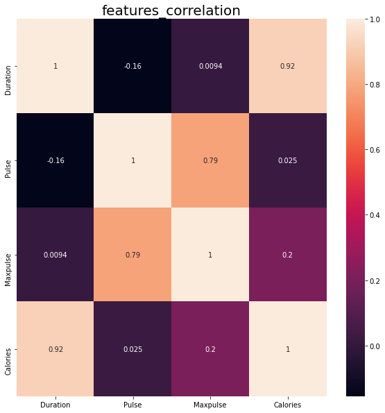

```python
plt.figure(figsize=(10,10))
sns.heatmap(correlation,annot=True)
plt.title("features_correlation",size=20)
```

[figure not shown]

## Pair Plot

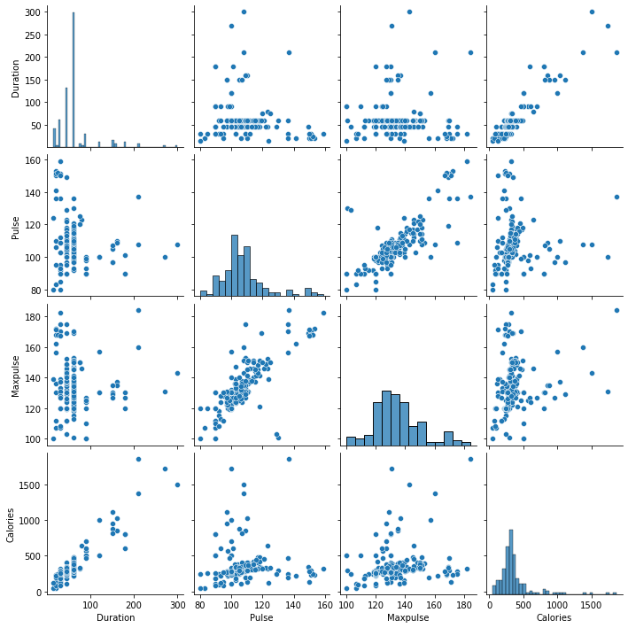

```python
sns.pairplot(data_input)
plt.show()
```

## scatter plot

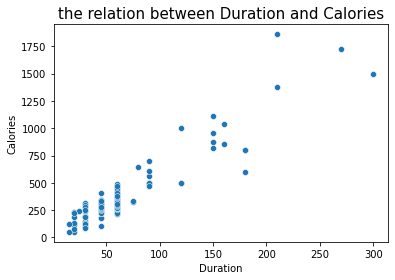

```python
sns.scatterplot(x=data_input["Duration"],y=data_input["Calories"])
plt.title("the relation between Duration and Calories",size=15)
plt.show()
```

# Scatter Plot

Specify that you want a scatter plot with the kind argument:

kind = 'scatter'

A scatter plot needs an x- and a y-axis.

In the example below we will use "Duration" for the x-axis and "Calories" for the y-axis.

Include the x and y arguments like this:

x = 'Duration', y = 'Calories

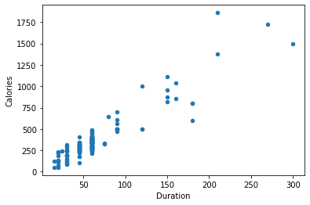

```python
import pandas as pd
import matplotlib.pyplot as plt

df = pd.read_csv('data _1.csv')

df.plot(kind = 'scatter', x = 'Duration', y = 'Calories')

plt.show()
```

# Histogram

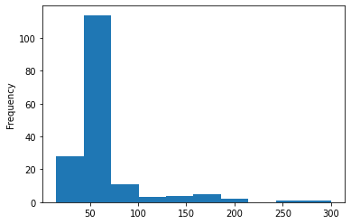

```python
df["Duration"].plot(kind = 'hist')
```

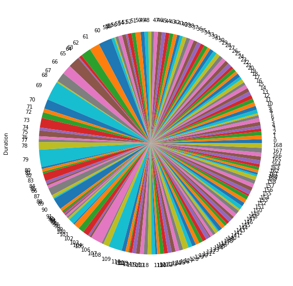

```python
plt.figure(figsize=(10,10))
df["Duration"].plot(kind="pie")
```

# Pandas - Analyzing DataFrames

## Viewing the Data

One of the most used method for getting a quick overview of the DataFrame, is the head() method.

The head() method returns the headers and a specified number of rows, starting from the top.

```python
#Get a quick overview by printing the first 10 rows of the DataFrame:
import pandas as pd

df = pd.read_csv('dataset/data.csv')

print(df.head(10))
```

```
   Duration  Pulse  Maxpulse  Calories
0        60    110       130     409.1
1        60    117       145     479.0
2        60    103       135     340.0
3        45    109       175     282.4
4        45    117       148     406.0
5        60    102       127     300.0
6        60    110       136     374.0
7        45    104       134     253.3
8        30    109       133     195.1
9        60     98       124     269.0
```

There is also a tail() method for viewing the last rows of the DataFrame.

The tail() method returns the headers and a specified number of rows, starting from the bottom.

```python
#Print the last 5 rows of the DataFrame:
print(df.tail())
```

```
     Duration  Pulse  Maxpulse  Calories
164        60    105       140     290.8
165        60    110       145     300.0
166        60    115       145     310.2
167        75    120       150     320.4
168        75    125       150     330.4
```

## Info About the Data

The DataFrames object has a method called info(), that gives you more information about the data set.

```python
print(df.info())
```

```
<class 'pandas.core.frame.DataFrame'>
RangeIndex: 169 entries, 0 to 168
Data columns (total 4 columns):
 #   Column    Non-Null Count  Dtype
---  ------    --------------  -----
 0   Duration  169 non-null    int64
 1   Pulse     169 non-null    int64
 2   Maxpulse  169 non-null    int64
 3   Calories  164 non-null    float64
dtypes: float64(1), int64(3)
memory usage: 5.4 KB
None
```

## Result Explained

The result tells us there are 169 rows and 4 columns:

### Null Values

The info() method also tells us how many Non-Null values there are present in each column, and in our data set it seems like there are 164 of 169 Non-Null values in the "Calories" column.

Which means that there are 5 rows with no value at all, in the "Calories" column, for whatever reason.

Empty values, or Null values, can be bad when analyzing data, and you should consider removing rows with empty values. This is a step towards what is called cleaning data, and you will learn more about that in the next chapters.

# Make Working With Data Delightful

Pandas DataFrames are data structures that contain:

**Data** organized in two dimensions, rows and columns

**Labels** that correspond to the rows and columns

```python
import pandas as pd
```

```python
data = {
   'name': ['Xavier', 'Ann', 'Jana', 'Yi', 'Robin', 'Amal', 'Nori'],
  'city': ['Mexico City', 'Toronto', 'Prague', 'Shanghai',
            'Manchester', 'Cairo', 'Osaka'],
  'age': [41, 28, 33, 34, 38, 31, 37],
   'py-score': [88.0, 79.0, 81.0, 80.0, 68.0, 61.0, 84.0]
 }

row_labels = [101, 102, 103, 104, 105, 106, 107]
```

```python
df = pd.DataFrame(data=data, index=row_labels)
```

```python
df.to_csv("city.csv")
```

```python
df
```

|  | name | city | age | py-score |
| --- | --- | --- | --- | --- |
| 101 | Xavier | Mexico City | 41 | 88.0 |
| 102 | Ann | Toronto | 28 | 79.0 |
| 103 | Jana | Prague | 33 | 81.0 |
| 104 | Yi | Shanghai | 34 | 80.0 |
| 105 | Robin | Manchester | 38 | 68.0 |
| 106 | Amal | Cairo | 31 | 61.0 |
| 107 | Nori | Osaka | 37 | 84.0 |

**Row** labels from 101 to 107

**Column** labels such as 'name', 'city', 'age', and 'py-score'

**Data** such as candidate names, cities, ages, and Python test scores

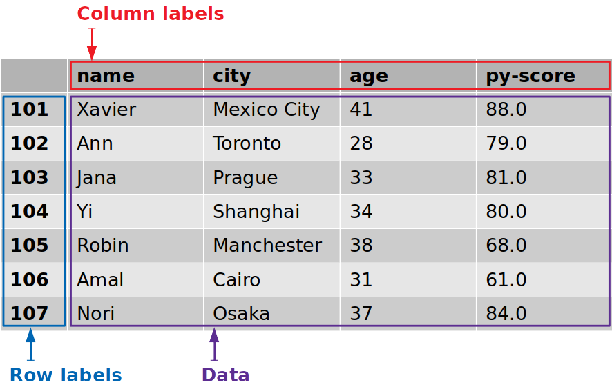

```python
df.head(n=2)
```

|  | name | city | age | py-score |
| --- | --- | --- | --- | --- |
| 101 | Xavier | Mexico City | 41 | 88.0 |
| 102 | Ann | Toronto | 28 | 79.0 |

```python
df.tail(n=2)
```

|  | name | city | age | py-score |
| --- | --- | --- | --- | --- |
| 106 | Amal | Cairo | 31 | 61.0 |
| 107 | Nori | Osaka | 37 | 84.0 |

You can access a column in a Pandas DataFrame the same way you would get a value from a dictionary:

```python
cities = df['city']
```

```python
cities
```

```
101    Mexico City
102        Toronto
103         Prague
104       Shanghai
105     Manchester
106          Cairo
107          Osaka
Name: city, dtype: object
```

```python
# dot notation
df.city
```

```
101    Mexico City
102        Toronto
103         Prague
104       Shanghai
105     Manchester
106          Cairo
107          Osaka
Name: city, dtype: object
```

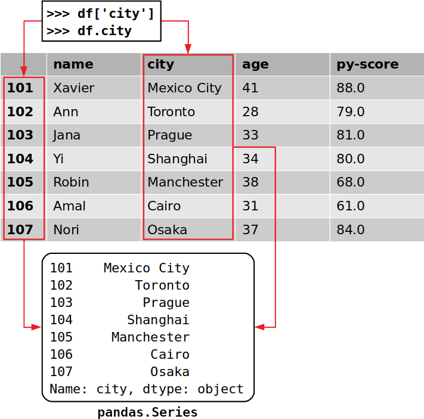

You can get a single item of a Series object the same way you would with a dictionary, by using its label as a key:

```python
cities[102]
```

```
'Toronto'
```

You can also access a whole row with the accessor .loc[]:

```python
df.loc[103]
```

```
name          Jana
city        Prague
age             33
py-score        81
Name: 103, dtype: object
```

This time, you’ve extracted the row that corresponds to the label 103, which contains the data for the candidate named Jana. In addition to the data values from this row, you’ve extracted the labels of the corresponding columns:

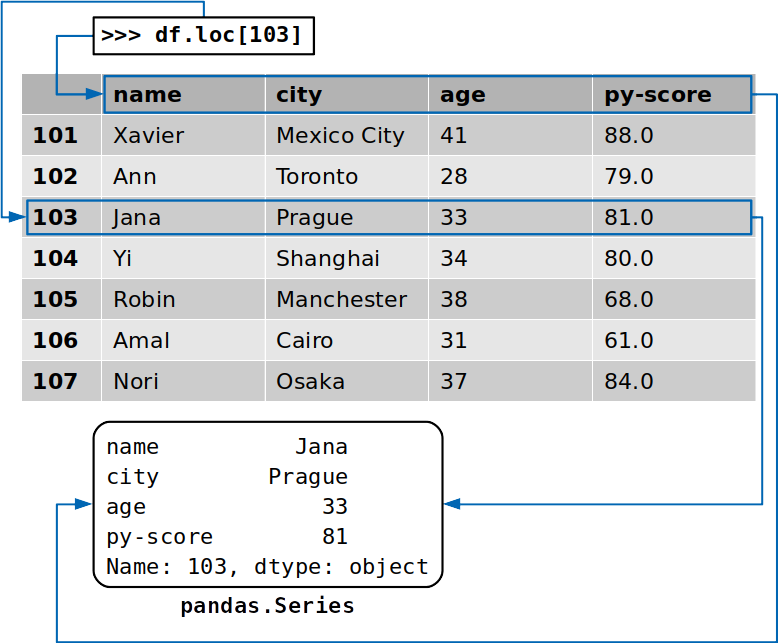

# Retrieving Labels and Data

```python
df.index
```

```
Int64Index([101, 102, 103, 104, 105, 106, 107], dtype='int64')
```

```python
df.columns
```

```
Index(['name', 'city', 'age', 'py-score'], dtype='object')
```

```python
df.columns[1]
```

```
'city'
```

```python
import numpy as np
df.index = np.arange(10, 17)
```

```python
df.index
```

```
Int64Index([10, 11, 12, 13, 14, 15, 16], dtype='int64')
```

```python
df["name"].values
```

```
array(['Xavier', 'Ann', 'Jana', 'Yi', 'Robin', 'Amal', 'Nori'],
      dtype=object)
```

```python
df["name"].value_counts()
```

```
Yi        1
Jana      1
Nori      1
Amal      1
Xavier    1
Robin     1
Ann       1
Name: name, dtype: int64
```

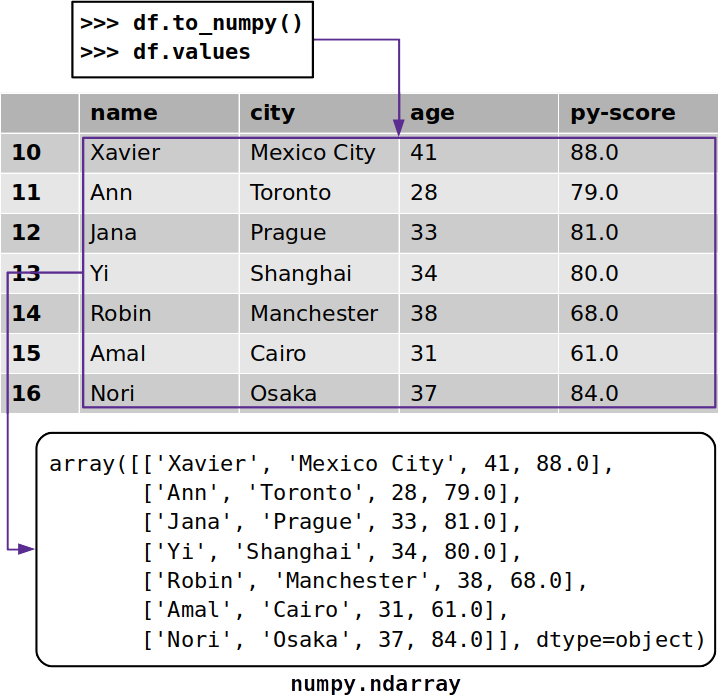

```python
df.to_numpy()
```

```
array([['Xavier', 'Mexico City', 41, 88.0],
       ['Ann', 'Toronto', 28, 79.0],
       ['Jana', 'Prague', 33, 81.0],
       ['Yi', 'Shanghai', 34, 80.0],
       ['Robin', 'Manchester', 38, 68.0],
       ['Amal', 'Cairo', 31, 61.0],
       ['Nori', 'Osaka', 37, 84.0]], dtype=object)
```

```python
df.values
```

```
array([['Xavier', 'Mexico City', 41, 88.0],
       ['Ann', 'Toronto', 28, 79.0],
       ['Jana', 'Prague', 33, 81.0],
       ['Yi', 'Shanghai', 34, 80.0],
       ['Robin', 'Manchester', 38, 68.0],
       ['Amal', 'Cairo', 31, 61.0],
       ['Nori', 'Osaka', 37, 84.0]], dtype=object)
```

The Pandas documentation suggests using .to_numpy() because of the flexibility offered by two optional parameters:

**dtype**: Use this parameter to specify the data type of the resulting array. It’s set to None by default.

**copy**: Set this parameter to False if you want to use the original data from the DataFrame. Set it to True if you want to make a copy of the data.

However, .values has been around for much longer than .to_numpy(), which was introduced in Pandas version 0.24.0. That means you’ll probably see .values more often, especially in older code.

## Data Types

The types of the data values, also called data types or dtypes, are important because they determine the amount of memory your DataFrame uses, as well as its calculation speed and level of precision.

```python
df.dtypes
```

```
name         object
city         object
age           int64
py-score    float64
dtype: object
```

If you want to modify the data type of one or more columns, then you can use .astype():

```python
df_ = df.astype(dtype={'age': np.int32, 'py-score': np.float32})
```

```python
df_.dtypes
```

```
name         object
city         object
age           int32
py-score    float32
dtype: object
```

```python
df_.ndim
```

```
2
```

```python
df_.shape
```

```
(7, 4)
```

```python
df_.size
```

```
28
```

DataFrame instances have two dimensions (rows and columns), so .ndim returns 2. A Series object, on the other hand, has only a single dimension, so in that case, .ndim would return 1.

The .shape attribute returns a tuple with the number of rows (in this case 7) and the number of columns (4). Finally, .size returns an integer equal to the number of values in the DataFrame (28).

## Accessing and Modifying Data

```python
df['name']
```

```
10    Xavier
11       Ann
12      Jana
13        Yi
14     Robin
15      Amal
16      Nori
Name: name, dtype: object
```

```python
df.loc[10]
```

```
name             Xavier
city        Mexico City
age                  41
py-score             88
Name: 10, dtype: object
```

```python
df.loc[10]
```

```
name             Xavier
city        Mexico City
age                  41
py-score             88
Name: 10, dtype: object
```

```python
df.iloc[0]
```

```
name             Xavier
city        Mexico City
age                  41
py-score             88
Name: 10, dtype: object
```

```python
df.loc[:, 'city']
```

```
10    Mexico City
11        Toronto
12         Prague
13       Shanghai
14     Manchester
15          Cairo
16          Osaka
Name: city, dtype: object
```

```python
df.iloc[:, 1]
```

```
10    Mexico City
11        Toronto
12         Prague
13       Shanghai
14     Manchester
15          Cairo
16          Osaka
Name: city, dtype: object
```

```python
df.loc[10:15, ['name', 'city']]
```

|  | name | city |
| --- | --- | --- |
| 10 | Xavier | Mexico City |
| 11 | Ann | Toronto |
| 12 | Jana | Prague |
| 13 | Yi | Shanghai |
| 14 | Robin | Manchester |
| 15 | Amal | Cairo |

```python
df.iloc[1:6, [0, 1]]
```

|  | name | city |
| --- | --- | --- |
| 11 | Ann | Toronto |
| 12 | Jana | Prague |
| 13 | Yi | Shanghai |
| 14 | Robin | Manchester |
| 15 | Amal | Cairo |

In this example, you use:

**Slices** to get the rows with the labels 11 through 15, which are equivalent to the indices 1 through 5

**Lists** to get the columns name and city, which are equivalent to the indices 0 and 1

```python
df.iloc[1:6:2, 0]
```

```
11     Ann
13      Yi
15    Amal
Name: name, dtype: object
```

```python
df.iloc[slice(1, 6, 2), 0]
```

```
11     Ann
13      Yi
15    Amal
Name: name, dtype: object
```

# Setting Data With Accessors

```python
df
```

|  | name | city | age | py-score |
| --- | --- | --- | --- | --- |
| 10 | Xavier | Mexico City | 41 | 88.0 |
| 11 | Ann | Toronto | 28 | 79.0 |
| 12 | Jana | Prague | 33 | 81.0 |
| 13 | Yi | Shanghai | 34 | 80.0 |
| 14 | Robin | Manchester | 38 | 68.0 |
| 15 | Amal | Cairo | 31 | 61.0 |
| 16 | Nori | Osaka | 37 | 84.0 |

```python
 df.loc[:, 'py-score']
```

```
10    88.0
11    79.0
12    81.0
13    80.0
14    68.0
15    61.0
16    84.0
Name: py-score, dtype: float64
```

```python
df.loc[:16, 'py-score'] = [40, 50, 60, 70,70,50,20]
```

```python
df.loc[10:, 'py-score'] = 0
```

```python
df['py-score']
```

```
10    0
11    0
12    0
13    0
14    0
15    0
16    0
Name: py-score, dtype: int64
```

```python
df.iloc[:, -1] = np.array([88.0, 79.0, 81.0, 80.0, 68.0, 61.0, 84.0])
```

```python
 df['py-score']
```

```
10    88.0
11    79.0
12    81.0
13    80.0
14    68.0
15    61.0
16    84.0
Name: py-score, dtype: float64
```

# Inserting and Deleting Data

```python
john = pd.Series(data=['John', 'Boston', 34, 79],
                  index=df.columns, name=17)
```

```python
john
```

```
name          John
city        Boston
age             34
py-score        79
Name: 17, dtype: object
```

```python
john.name
```

```
17
```

```python
df = df.append(john)
```

```python
df
```

|  | name | city | age | py-score |
| --- | --- | --- | --- | --- |
| 10 | Xavier | Mexico City | 41 | 88.0 |
| 11 | Ann | Toronto | 28 | 79.0 |
| 12 | Jana | Prague | 33 | 81.0 |
| 13 | Yi | Shanghai | 34 | 80.0 |
| 14 | Robin | Manchester | 38 | 68.0 |
| 15 | Amal | Cairo | 31 | 61.0 |
| 16 | Nori | Osaka | 37 | 84.0 |
| 17 | John | Boston | 34 | 79.0 |

```python
df = df.drop(labels=[17])
```

```python
df
```

|  | name | city | age | py-score |
| --- | --- | --- | --- | --- |
| 10 | Xavier | Mexico City | 41 | 88.0 |
| 11 | Ann | Toronto | 28 | 79.0 |
| 12 | Jana | Prague | 33 | 81.0 |
| 13 | Yi | Shanghai | 34 | 80.0 |
| 14 | Robin | Manchester | 38 | 68.0 |
| 15 | Amal | Cairo | 31 | 61.0 |
| 16 | Nori | Osaka | 37 | 84.0 |

# Inserting and Deleting Columns

```python
df['js-score'] = np.array([71.0, 95.0, 88.0, 79.0, 91.0, 91.0, 80.0])
df
```

|  | name | city | age | py-score | js-score |
| --- | --- | --- | --- | --- | --- |
| 10 | Xavier | Mexico City | 41 | 88.0 | 71.0 |
| 11 | Ann | Toronto | 28 | 79.0 | 95.0 |
| 12 | Jana | Prague | 33 | 81.0 | 88.0 |
| 13 | Yi | Shanghai | 34 | 80.0 | 79.0 |
| 14 | Robin | Manchester | 38 | 68.0 | 91.0 |
| 15 | Amal | Cairo | 31 | 61.0 | 91.0 |
| 16 | Nori | Osaka | 37 | 84.0 | 80.0 |

```python
df['total-score'] = 0.0
```

```python
df
```

|  | name | city | age | py-score | js-score | total-score |
| --- | --- | --- | --- | --- | --- | --- |
| 10 | Xavier | Mexico City | 41 | 88.0 | 71.0 | 0.0 |
| 11 | Ann | Toronto | 28 | 79.0 | 95.0 | 0.0 |
| 12 | Jana | Prague | 33 | 81.0 | 88.0 | 0.0 |
| 13 | Yi | Shanghai | 34 | 80.0 | 79.0 | 0.0 |
| 14 | Robin | Manchester | 38 | 68.0 | 91.0 | 0.0 |
| 15 | Amal | Cairo | 31 | 61.0 | 91.0 | 0.0 |
| 16 | Nori | Osaka | 37 | 84.0 | 80.0 | 0.0 |

You’ve just inserted another column with the score of the Django test. The parameter loc determines the location, or the zero-based index, of the new column in the Pandas DataFrame. column sets the label of the new column, and value specifies the data values to insert.

```python
df.insert(loc=4, column='django-score',
         value=np.array([86.0, 81.0, 78.0, 88.0, 74.0, 70.0, 81.0]))
```

```python
df
```

|  | name | city | age | py-score | django-score | js-score | total-score |
| --- | --- | --- | --- | --- | --- | --- | --- |
| 10 | Xavier | Mexico City | 41 | 88.0 | 86.0 | 71.0 | 0.0 |
| 11 | Ann | Toronto | 28 | 79.0 | 81.0 | 95.0 | 0.0 |
| 12 | Jana | Prague | 33 | 81.0 | 78.0 | 88.0 | 0.0 |
| 13 | Yi | Shanghai | 34 | 80.0 | 88.0 | 79.0 | 0.0 |
| 14 | Robin | Manchester | 38 | 68.0 | 74.0 | 91.0 | 0.0 |
| 15 | Amal | Cairo | 31 | 61.0 | 70.0 | 91.0 | 0.0 |
| 16 | Nori | Osaka | 37 | 84.0 | 81.0 | 80.0 | 0.0 |

```python
df = df.drop(labels='age', axis=1)
df
```

|  | name | city | py-score | django-score | js-score | total-score |
| --- | --- | --- | --- | --- | --- | --- |
| 10 | Xavier | Mexico City | 88.0 | 86.0 | 71.0 | 0.0 |
| 11 | Ann | Toronto | 79.0 | 81.0 | 95.0 | 0.0 |
| 12 | Jana | Prague | 81.0 | 78.0 | 88.0 | 0.0 |
| 13 | Yi | Shanghai | 80.0 | 88.0 | 79.0 | 0.0 |
| 14 | Robin | Manchester | 68.0 | 74.0 | 91.0 | 0.0 |
| 15 | Amal | Cairo | 61.0 | 70.0 | 91.0 | 0.0 |
| 16 | Nori | Osaka | 84.0 | 81.0 | 80.0 | 0.0 |

# Sorting a Pandas DataFrame

You can sort a Pandas DataFrame with .sort_values():

```python
df.sort_values(by='js-score', ascending=False)
```

|  | name | city | py-score | django-score | js-score | total-score |
| --- | --- | --- | --- | --- | --- | --- |
| 11 | Ann | Toronto | 79.0 | 81.0 | 95.0 | 0.0 |
| 14 | Robin | Manchester | 68.0 | 74.0 | 91.0 | 0.0 |
| 15 | Amal | Cairo | 61.0 | 70.0 | 91.0 | 0.0 |
| 12 | Jana | Prague | 81.0 | 78.0 | 88.0 | 0.0 |
| 16 | Nori | Osaka | 84.0 | 81.0 | 80.0 | 0.0 |
| 13 | Yi | Shanghai | 80.0 | 88.0 | 79.0 | 0.0 |
| 10 | Xavier | Mexico City | 88.0 | 86.0 | 71.0 | 0.0 |

```python
df['total']= [84,81,82,87,71,72,73]
```

```python
df.sort_values(by=['total', 'py-score'], ascending=[False, False])
```

|  | name | city | py-score | django-score | js-score | total-score | total |
| --- | --- | --- | --- | --- | --- | --- | --- |
| 13 | Yi | Shanghai | 80.0 | 88.0 | 79.0 | 0.0 | 87 |
| 10 | Xavier | Mexico City | 88.0 | 86.0 | 71.0 | 0.0 | 84 |
| 12 | Jana | Prague | 81.0 | 78.0 | 88.0 | 0.0 | 82 |
| 11 | Ann | Toronto | 79.0 | 81.0 | 95.0 | 0.0 | 81 |
| 16 | Nori | Osaka | 84.0 | 81.0 | 80.0 | 0.0 | 73 |
| 15 | Amal | Cairo | 61.0 | 70.0 | 91.0 | 0.0 | 72 |
| 14 | Robin | Manchester | 68.0 | 74.0 | 91.0 | 0.0 | 71 |

# Filtering Data

Data filtering is another powerful feature of Pandas. It works similarly to indexing with Boolean arrays in NumPy.

If you apply some logical operation on a Series object, then you’ll get another Series with the Boolean values True and False:

```python
filter_ = df['django-score'] >= 80
```

```python
filter_
```

```
10     True
11     True
12    False
13     True
14    False
15    False
16     True
Name: django-score, dtype: bool
```

```python
df[filter_]
```

|  | name | city | py-score | django-score | js-score | total-score | total |
| --- | --- | --- | --- | --- | --- | --- | --- |
| 10 | Xavier | Mexico City | 88.0 | 86.0 | 71.0 | 0.0 | 84 |
| 11 | Ann | Toronto | 79.0 | 81.0 | 95.0 | 0.0 | 81 |
| 13 | Yi | Shanghai | 80.0 | 88.0 | 79.0 | 0.0 | 87 |
| 16 | Nori | Osaka | 84.0 | 81.0 | 80.0 | 0.0 | 73 |

```python
df[(df['py-score'] >= 80) & (df['js-score'] >= 80)]
```

|  | name | city | py-score | django-score | js-score | total-score | total |
| --- | --- | --- | --- | --- | --- | --- | --- |
| 12 | Jana | Prague | 81.0 | 78.0 | 88.0 | 0.0 | 82 |
| 16 | Nori | Osaka | 84.0 | 81.0 | 80.0 | 0.0 | 73 |

In this example, the condition is df['django-score'] >= 80. The values of the DataFrame or Series that calls .where() will remain the same where the condition is True and will be replaced with the value of other (in this case 0.0) where the condition is False.

```python
df['django-score'].where(cond=df['django-score'] >= 80, other=0.0)
```

```
10    86.0
11    81.0
12     0.0
13    88.0
14     0.0
15     0.0
16    81.0
Name: django-score, dtype: float64
```

# Handling Missing Data

```python
df_ = pd.DataFrame({'x': [1, 2, np.nan, 4]})
```

```python
 df_
```

|  | x |
| --- | --- |
| 0 | 1.0 |
| 1 | 2.0 |
| 2 | NaN |
| 3 | 4.0 |

## Calculating With Missing Data

```python
df_.mean()
```

```
x    2.333333
dtype: float64
```

## Filling Missing Data

Pandas has several options for filling, or replacing, missing values with other values. One of the most convenient methods is .fillna(). You can use it to replace missing values with:

```
Specified values
The values above the missing value
The values below the missing value
```

```python
df_.fillna(value=0)
```

|  | x |
| --- | --- |
| 0 | 1.0 |
| 1 | 2.0 |
| 2 | 0.0 |
| 3 | 4.0 |

```python
df_.fillna(method='ffill')
```

|  | x |
| --- | --- |
| 0 | 1.0 |
| 1 | 2.0 |
| 2 | 2.0 |
| 3 | 4.0 |

```python
df_.fillna(method='bfill')
```

|  | x |
| --- | --- |
| 0 | 1.0 |
| 1 | 2.0 |
| 2 | 4.0 |
| 3 | 4.0 |

In the first example, .fillna(value=0) replaces the missing value with 0.0, which you specified with value. In the second example, .fillna(method='ffill') replaces the missing value with the value above it, which is 2.0. In the third example, .fillna(method='bfill') uses the value below the missing value, which is 4.0.

```python
df_.interpolate()
```

|  | x |
| --- | --- |
| 0 | 1.0 |
| 1 | 2.0 |
| 2 | 3.0 |
| 3 | 4.0 |

## Deleting Rows and Columns With Missing Data

```python
df_.dropna()
```

|  | x |
| --- | --- |
| 0 | 1.0 |
| 1 | 2.0 |
| 3 | 4.0 |

# Plotting With Pandas DataFrames

```python
import matplotlib.pyplot as plt
```

```python
df=pd.read_csv("city.csv",index_col=0)
df
```

|  | name | city | age | py-score |
| --- | --- | --- | --- | --- |
| 101 | Xavier | Mexico City | 41 | 88.0 |
| 102 | Ann | Toronto | 28 | 79.0 |
| 103 | Jana | Prague | 33 | 81.0 |
| 104 | Yi | Shanghai | 34 | 80.0 |
| 105 | Robin | Manchester | 38 | 68.0 |
| 106 | Amal | Cairo | 31 | 61.0 |
| 107 | Nori | Osaka | 37 | 84.0 |

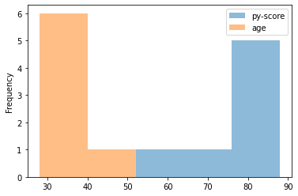

```python
df.loc[:, ['py-score', 'age']].plot.hist(bins=5, alpha=0.5)
plt.show()
```

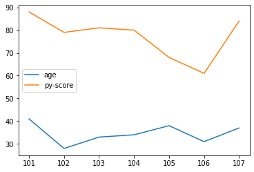

```python
df.plot()
plt.show()
```

# Scatter Plot

Specify that you want a scatter plot with the kind argument:

kind = 'scatter'

A scatter plot needs an x- and a y-axis.

In the example below we will use "Duration" for the x-axis and "Calories" for the y-axis.

Include the x and y arguments like this:

x = 'Duration', y = 'Calories

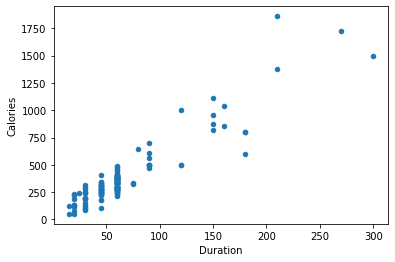

```python
import pandas as pd
import matplotlib.pyplot as plt

df = pd.read_csv('dataset//data.csv')

df.plot(kind = 'scatter', x = 'Duration', y = 'Calories')

plt.show()
```

# Histogram

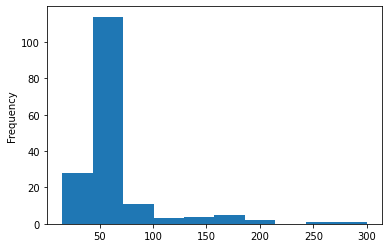

```python
df["Duration"].plot(kind = 'hist')
```

# How to compute some basic statistics

Pandas provides many statistical methods for DataFrames. You can get basic statistics for the numerical columns of a Pandas DataFrame with .describe():

```python
df.describe()
```

|  | Duration | Pulse | Maxpulse | Calories |
| --- | --- | --- | --- | --- |
| count | 169.000000 | 169.000000 | 169.000000 | 164.000000 |
| mean | 63.846154 | 107.461538 | 134.047337 | 375.790244 |
| std | 42.299949 | 14.510259 | 16.450434 | 266.379919 |
| min | 15.000000 | 80.000000 | 100.000000 | 50.300000 |
| 25% | 45.000000 | 100.000000 | 124.000000 | 250.925000 |
| 50% | 60.000000 | 105.000000 | 131.000000 | 318.600000 |
| 75% | 60.000000 | 111.000000 | 141.000000 | 387.600000 |
| max | 300.000000 | 159.000000 | 184.000000 | 1860.400000 |

```python
df.mean()
```

```
Duration     63.846154
Pulse       107.461538
Maxpulse    134.047337
Calories    375.790244
dtype: float64
```

```python
df['Duration'].mean()
```

```
63.84615384615385
```

```python
df.std()
```

```
Duration     42.299949
Pulse        14.510259
Maxpulse     16.450434
Calories    266.379919
dtype: float64
```

```python
df['Duration'].std()
```

```
42.299949341408286
```

```python
df1= pd.DataFrame({"column_a":[1,2,3,4],"column_b":["a","b","c","d"],"column_c":[True,True,False,True]})
```

```python
df1.to_csv("df1.csv")
```

```python
df1=pd.read_csv("df1.csv",index_col=0)
df1
```

|  | column_a | column_b | column_c |
| --- | --- | --- | --- |
| 0 | 1 | a | True |
| 1 | 2 | b | True |
| 2 | 3 | c | False |
| 3 | 4 | d | True |

```python
df2= pd.DataFrame({"column_a":[1,2,9,10],"column_b":["a","k","r","Q"],"column_c":[False,False,False,True]})
```

```python
df2.to_csv("df2.csv")
```

```python
df2=pd.read_csv("df2.csv",index_col=0)
df2
```

|  | column_a | column_b | column_c |
| --- | --- | --- | --- |
| 0 | 1 | a | False |
| 1 | 2 | k | False |
| 2 | 9 | r | False |
| 3 | 10 | Q | True |